# Sapling models for Tony & Kevin

Kathleen Stutzman

2024-01-26

Hidden below is code for importing the data set and log transforming variables. The best model (lowest AIC & using lrtest) is presented below, model fit checked, and pairwise comparison for Treatment Type.

I did create and test models without treatment type, but they always have higher AIC and worse model fit that those with (probably due to the control category…)

##### Variables investigated:

- **Treat_Type** - treatment type
- **PIRI** - pitch pine sapling count (25m<sup>2</sup>)
- **SO** - shrub oak sapling count (25m<sup>2</sup>)
- **other** - other seedling count (25m<sup>2</sup>)
- **BA_HA** - basal area per hectare
- **BA_piri** - pitch pine basal area per hectare
- **Mineral** - exposed mineral soil (1m<sup>2</sup>)
- **avgLD** - average leaf litter depth (1m<sup>2</sup>)
- **Veg_Total** - total understory plant cover (1m<sup>2</sup>)
- **TFT** - time between treatment and sampling (used as an offset)
- **Site/Plot_No** - random effect of plots within sites

*Variables are standardized (_s)*

# Pitch Pine Regeneration

### Best pitch pine sapling model

```r
sa.m9s <- glmmTMB(PIRI ~ Treat_Type + ba.ha_s + other_s + avgld_s + offset(l.TFT) + (1|Site/Plot_No),
                 data = sa.all3,
                 ziformula = ~Region,
                 family = nbinom2)
summary(sa.m9s)
```

```
##  Family: nbinom2  ( log )
## Formula:
## PIRI ~ Treat_Type + ba.ha_s + other_s + avgld_s + offset(l.TFT) +
##     (1 | Site/Plot_No)
## Zero inflation:        ~Region
## Data: sa.all3
##
##      AIC      BIC   logLik deviance df.resid
##    245.8    313.2   -106.9    213.8      482
##
## Random effects:
##
## Conditional model:
##  Groups       Name        Variance      Std.Dev.
##  Plot_No:Site (Intercept) 0.00000003136 0.0001771
##  Site         (Intercept) 1.00553141354 1.0027619
## Number of obs: 498, groups:  Plot_No:Site, 498; Site, 47
##
## Dispersion parameter for nbinom2 family (): 0.332
##
## Conditional model:
##                    Estimate Std. Error z value       Pr(>|z|)
## (Intercept)         -5.4223     0.8811  -6.154 0.000000000755 ***
## Treat_TypeFallRx    -0.2051     0.9401  -0.218         0.8273
## Treat_TypeHarvest    1.8988     1.3009   1.460         0.1444
## Treat_TypeMowRx      1.6541     1.0395   1.591         0.1116
## Treat_TypeSpringRx  -0.2551     1.4500  -0.176         0.8603
## ba.ha_s              0.8721     0.3623   2.407         0.0161 *
## other_s             -1.1511     0.6811  -1.690         0.0910 .
## avgld_s             -0.2776     0.2909  -0.954         0.3398
## ---
## Signif. codes:  0 '***' 0.001 '**' 0.01 '*' 0.05 '.' 0.1 ' ' 1
##
## Zero-inflation model:
##              Estimate Std. Error z value Pr(>|z|)
## (Intercept)     1.521      1.019   1.492    0.136
## RegionLI       22.406  53458.279   0.000    1.000
## RegionMA      -20.529  22550.145  -0.001    0.999
## RegionME       -2.795      3.323  -0.841    0.400
## RegionNH       -1.687      1.457  -1.158    0.247
```

### Check model fit

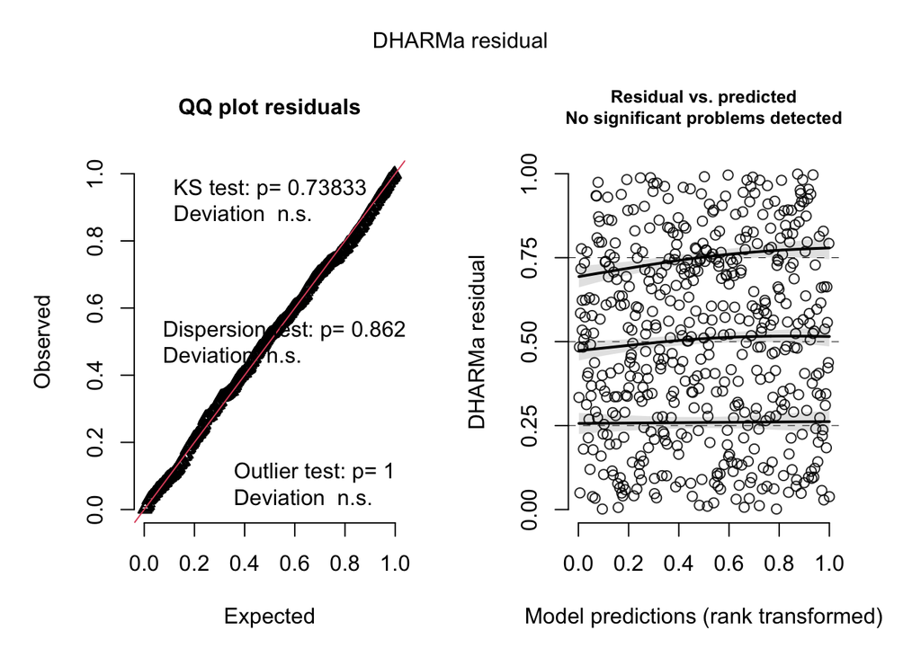

```r
sa.m9s_sr <- simulateResiduals(sa.m9s, n = 1000, plot = T) #passes
```

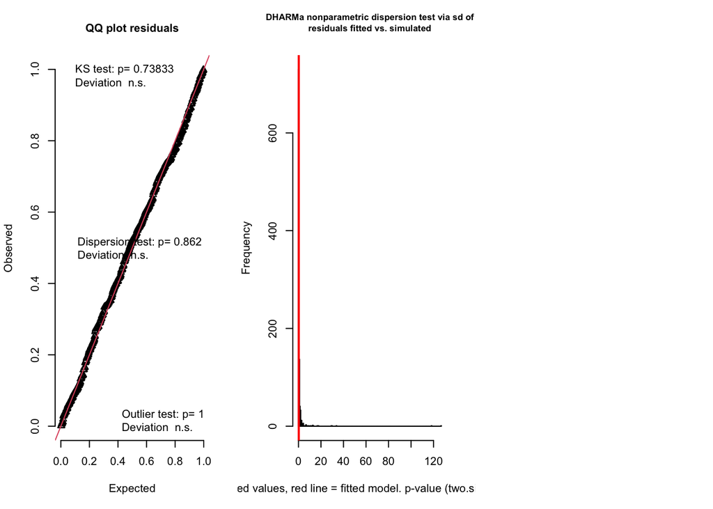

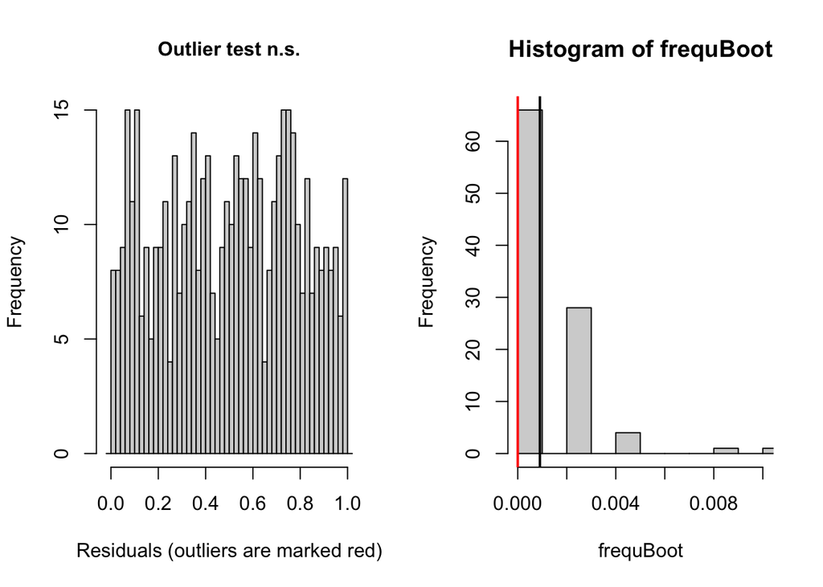

```
## $uniformity
##
##  Asymptotic one-sample Kolmogorov-Smirnov test
##
## data:  simulationOutput$scaledResiduals
## D = 0.030633, p-value = 0.7383
## alternative hypothesis: two-sided
##
##
## $dispersion
##
##  DHARMa nonparametric dispersion test via sd of residuals fitted vs.
##  simulated
##
## data:  simulationOutput
## dispersion = 0.30204, p-value = 0.862
## alternative hypothesis: two.sided
##
##
## $outliers
##
##  DHARMa bootstrapped outlier test
##
## data:  simulationOutput
## outliers at both margin(s) = 0, observations = 498, p-value = 1
## alternative hypothesis: two.sided
##  percent confidence interval:
##  0.000000000 0.004016064
## sample estimates:
## outlier frequency (expected: 0.000903614457831325 )
##                                                   0
```

```
## $uniformity
##
##  Asymptotic one-sample Kolmogorov-Smirnov test
##
## data:  simulationOutput$scaledResiduals
## D = 0.030633, p-value = 0.7383
## alternative hypothesis: two-sided
##
##
## $dispersion
##
##  DHARMa nonparametric dispersion test via sd of residuals fitted vs.
##  simulated
##
## data:  simulationOutput
## dispersion = 0.30204, p-value = 0.862
## alternative hypothesis: two.sided
##
##
## $outliers
##
##  DHARMa bootstrapped outlier test
##
## data:  simulationOutput
## outliers at both margin(s) = 0, observations = 498, p-value = 1
## alternative hypothesis: two.sided
##  percent confidence interval:
##  0.000000000 0.004016064
## sample estimates:
## outlier frequency (expected: 0.000903614457831325 )
##                                                   0
```

```r
testResiduals(sa.m9s_sr) #passes
```

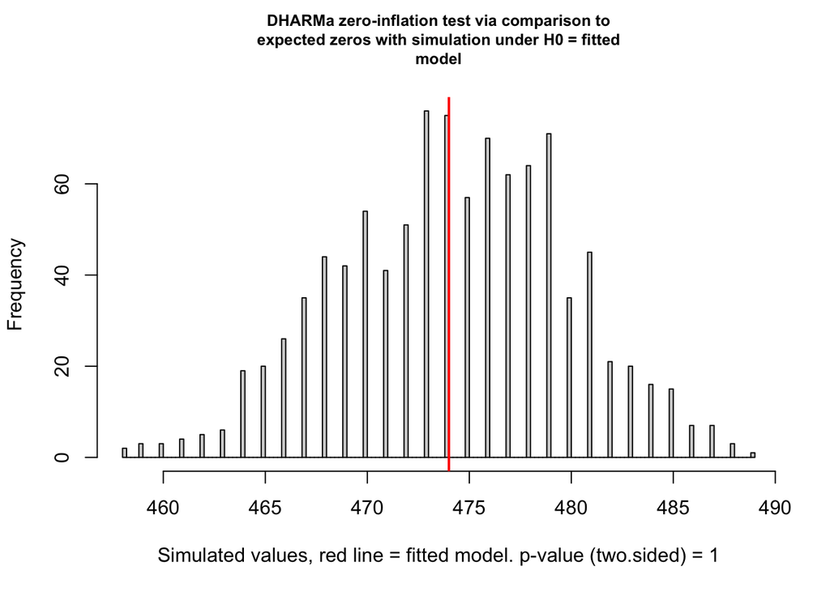

```
##
##  DHARMa zero-inflation test via comparison to expected zeros with
##  simulation under H0 = fitted model
##
## data:  simulationOutput
## ratioObsSim = 0.99934, p-value = 1
## alternative hypothesis: two.sided
```

```r
testZeroInflation(sa.m9s_sr)
```

### Pairwise comparison for treatment types

```r
emmeans(sa.m9s, specs = pairwise ~ Treat_Type, adjust = 'Tukey', type = 'response')
```

```
## $emmeans
##  Treat_Type response     SE  df asymp.LCL asymp.UCL
##  Control      0.0268 0.0236 Inf   0.00477     0.151
##  FallRx       0.0219 0.0206 Inf   0.00345     0.139
##  Harvest      0.1792 0.1821 Inf   0.02444     1.314
##  MowRx        0.1403 0.1040 Inf   0.03279     0.600
##  SpringRx     0.0208 0.0280 Inf   0.00148     0.292
##
## Confidence level used: 0.95
## Intervals are back-transformed from the log scale
##
## $contrasts
##  contrast           ratio     SE  df null z.ratio p.value
##  Control / FallRx   1.228  1.154 Inf    1   0.218  0.9995
##  Control / Harvest  0.150  0.195 Inf    1  -1.460  0.5889
##  Control / MowRx    0.191  0.199 Inf    1  -1.591  0.5030
##  Control / SpringRx 1.291  1.871 Inf    1   0.176  0.9998
##  FallRx / Harvest   0.122  0.166 Inf    1  -1.542  0.5352
##  FallRx / MowRx     0.156  0.170 Inf    1  -1.704  0.4314
##  FallRx / SpringRx  1.051  1.577 Inf    1   0.033  1.0000
##  Harvest / MowRx    1.277  1.562 Inf    1   0.200  0.9996
##  Harvest / SpringRx 8.619 14.264 Inf    1   1.302  0.6903
##  MowRx / SpringRx   6.748 10.028 Inf    1   1.285  0.7008
##
## P value adjustment: tukey method for comparing a family of 5 estimates
## Tests are performed on the log scale
```

##### None signficantly different from the other; generally not a lot of pitch pine saplings measured

### Plot models

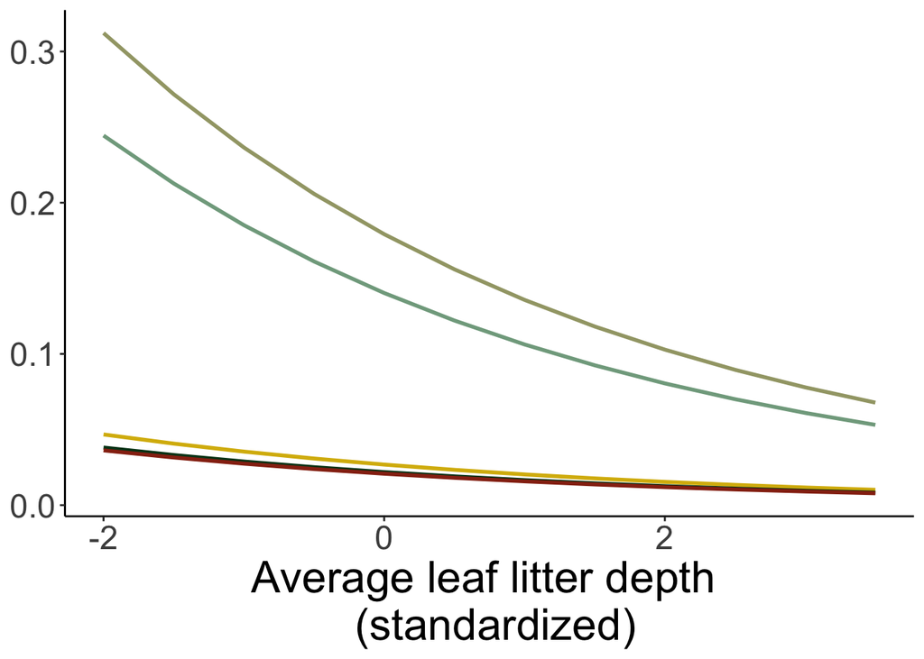

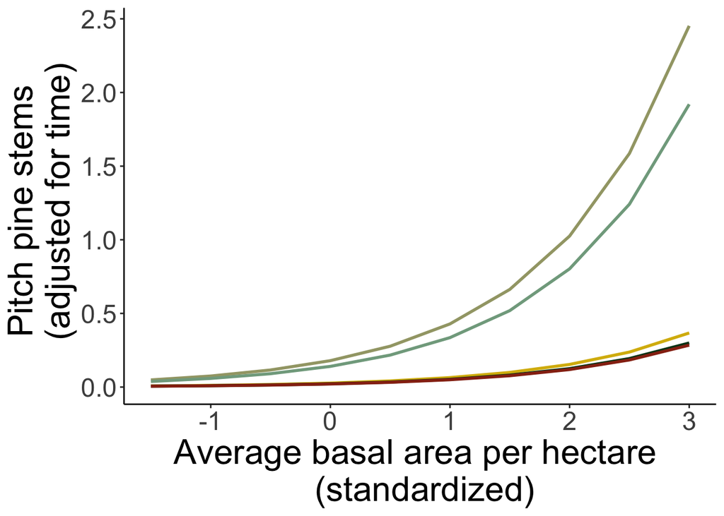

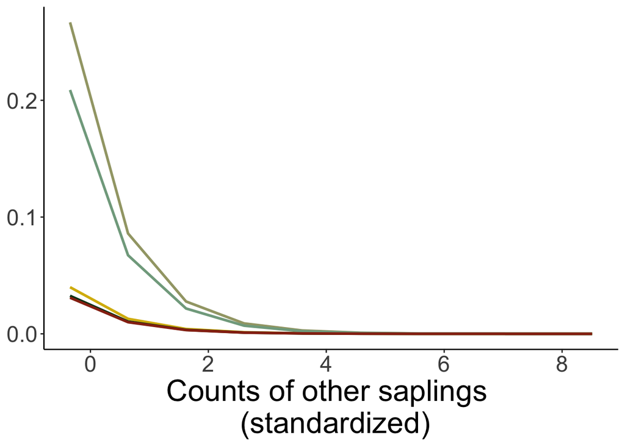

# Shrub Oak Regeneration

This includes QUIL (scrub oak) & QUPR (dwarf chinkapin oak)

#### looking at SO w/o spring rx or mowrx and w/ standardized variables

There is was no shrub oak sapling recorded in SpringRx or MowRx treatments

```r
sa.all_noSMRX <- sa.all3 %>%
  filter(Treat_Type != "SpringRx") %>%
  filter(Treat_Type != "MowRx")
```

### Best model

```r
so.sa7s <- glmmTMB(Shrub_Oak ~ Treat_Type + offset(l.TFT) + (1|Site/Plot_No),
                 data = sa.all_noSMRX,
                 ziformula = ~Region,
                 family = nbinom1)
summary(so.sa7s) #323.8
```

```
##  Family: nbinom1  ( log )
## Formula:          Shrub_Oak ~ Treat_Type + offset(l.TFT) + (1 | Site/Plot_No)
## Zero inflation:             ~Region
## Data: sa.all_noSMRX
##
##      AIC      BIC   logLik deviance df.resid
##    323.8    363.6   -150.9    301.8      264
##
## Random effects:
##
## Conditional model:
##  Groups       Name        Variance       Std.Dev.
##  Plot_No:Site (Intercept) 0.000000007557 0.00008693
##  Site         (Intercept) 0.109978958497 0.33163076
## Number of obs: 275, groups:  Plot_No:Site, 275; Site, 26
##
## Dispersion parameter for nbinom1 family (): 0.773
##
## Conditional model:
##                   Estimate Std. Error z value            Pr(>|z|)
## (Intercept)        -2.6952     0.2583 -10.435 <0.0000000000000002 ***
## Treat_TypeFallRx    0.8099     0.3689   2.195              0.0281 *
## Treat_TypeHarvest   1.5834     1.2203   1.298              0.1944
## ---
## Signif. codes:  0 '***' 0.001 '**' 0.01 '*' 0.05 '.' 0.1 ' ' 1
##
## Zero-inflation model:
##                 Estimate   Std. Error z value Pr(>|z|)
## (Intercept)       1.9034       0.7926   2.402   0.0163 *
## RegionLI         30.0378 1411573.3749   0.000   1.0000
## RegionMA          2.0029       1.3083   1.531   0.1258
## RegionME        -31.2661  873734.0264   0.000   1.0000
## RegionNH         -1.0435       0.8939  -1.167   0.2431
## ---
## Signif. codes:  0 '***' 0.001 '**' 0.01 '*' 0.05 '.' 0.1 ' ' 1
```

### DHARMa test

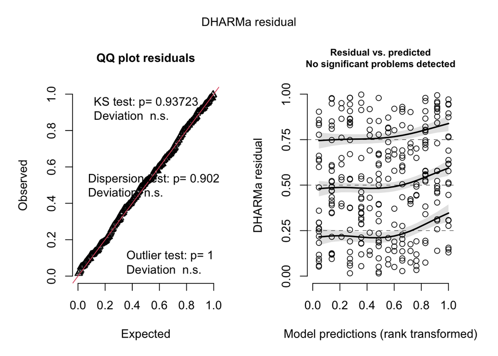

```r
so.sa7s_sr <- simulateResiduals(so.sa7s, n = 1000, plot = T) #passes
```

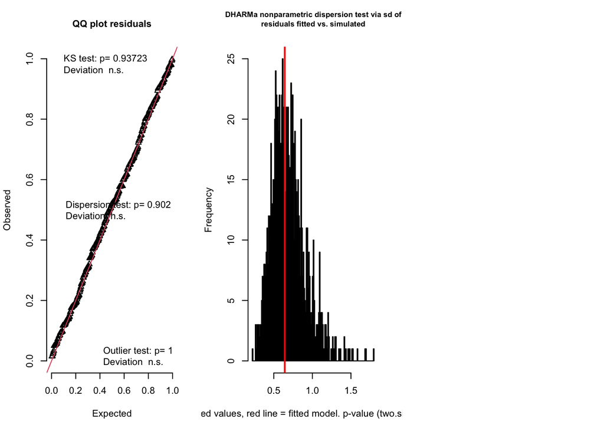

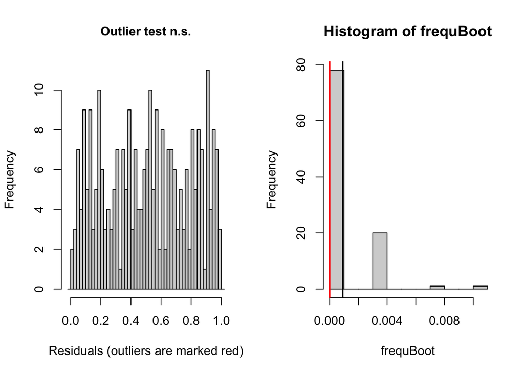

```
## $uniformity
##
##  Asymptotic one-sample Kolmogorov-Smirnov test
##
## data:  simulationOutput$scaledResiduals
## D = 0.032251, p-value = 0.9372
## alternative hypothesis: two-sided
##
##
## $dispersion
##
##  DHARMa nonparametric dispersion test via sd of residuals fitted vs.
##  simulated
##
## data:  simulationOutput
## dispersion = 0.9179, p-value = 0.902
## alternative hypothesis: two.sided
##
##
## $outliers
##
##  DHARMa bootstrapped outlier test
##
## data:  simulationOutput
## outliers at both margin(s) = 0, observations = 275, p-value = 1
## alternative hypothesis: two.sided
##  percent confidence interval:
##  0.000000000 0.003636364
## sample estimates:
## outlier frequency (expected: 0.000909090909090909 )
##                                                   0
```

```
## $uniformity
##
##  Asymptotic one-sample Kolmogorov-Smirnov test
##
## data:  simulationOutput$scaledResiduals
## D = 0.032251, p-value = 0.9372
## alternative hypothesis: two-sided
##
##
## $dispersion
##
##  DHARMa nonparametric dispersion test via sd of residuals fitted vs.
##  simulated
##
## data:  simulationOutput
## dispersion = 0.9179, p-value = 0.902
## alternative hypothesis: two.sided
##
##
## $outliers
##
##  DHARMa bootstrapped outlier test
##
## data:  simulationOutput
## outliers at both margin(s) = 0, observations = 275, p-value = 1
## alternative hypothesis: two.sided
##  percent confidence interval:
##  0.000000000 0.003636364
## sample estimates:
## outlier frequency (expected: 0.000909090909090909 )
##                                                   0
```

```r
testResiduals(so.sa7s_sr)  #passes
```

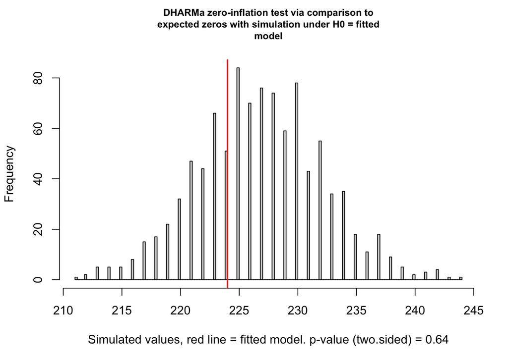

```
##
##  DHARMa zero-inflation test via comparison to expected zeros with
##  simulation under H0 = fitted model
##
## data:  simulationOutput
## ratioObsSim = 0.98732, p-value = 0.64
## alternative hypothesis: two.sided
```

```r
testZeroInflation(so.sa7s_sr)
```

### Pairwise

```r
emmeans(so.sa7s, specs = pairwise ~ Treat_Type, adjust = 'Tukey', type = 'response')
```

```
## $emmeans
##  Treat_Type response    SE  df asymp.LCL asymp.UCL
##  Control       0.722 0.187 Inf     0.435      1.20
##  FallRx        1.623 0.590 Inf     0.796      3.31
##  Harvest       3.518 4.244 Inf     0.331     37.42
##
## Confidence level used: 0.95
## Intervals are back-transformed from the log scale
##
## $contrasts
##  contrast          ratio    SE  df null z.ratio p.value
##  Control / FallRx  0.445 0.164 Inf    1  -2.195  0.0719
##  Control / Harvest 0.205 0.250 Inf    1  -1.298  0.3965
##  FallRx / Harvest  0.461 0.570 Inf    1  -0.626  0.8056
##
## P value adjustment: tukey method for comparing a family of 3 estimates
## Tests are performed on the log scale
```

#### none significantly different

Control vs FallRx close at 0.07

### Plot model

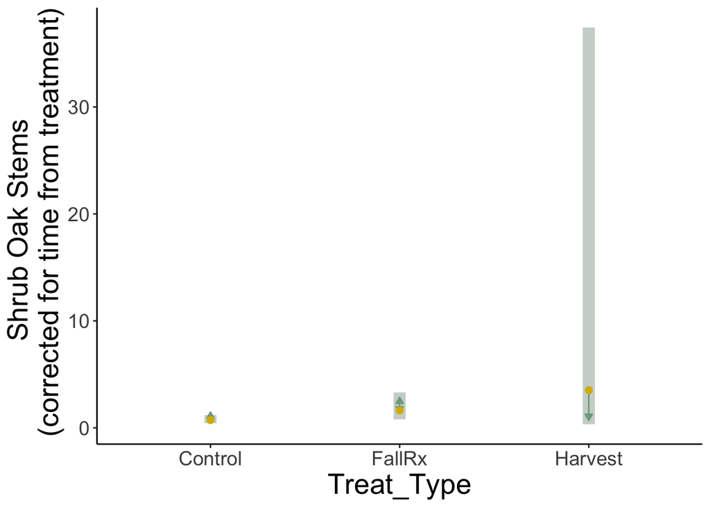

More in harvest - does fire kill large shrub oak saplings? They are entirely missing from springrx and mowrx treatments